# Data 621 Assignment 4

Mark Gonsalves, Joshua Hummell, Claire Meyer, Chinedu Onyeka, Rathish Parayil Sasidharan

April 12th, 2022

### **Overview**

In this homework assignment, you will explore, analyze and model a data set containing approximately 8000 records representing a customer at an auto insurance company. Each record has two response variables. The first response variable, TARGET_FLAG, is a 1 or a 0. A “1” means that the person was in a car crash. A zero means that the person was not in a car crash. The second response variable is TARGET_AMT. This value is zero if the person did not crash their car. But if they did crash their car, this number will be a value greater than zero.  
Your objective is to build multiple linear regression and binary logistic regression models on the training data to predict the probability that a person will crash their car and also the amount of money it will cost if the person does crash their car. You can only use the variables given to you (or variables that you derive from the variables provided). Below is a short description of the variables of interest in the data set:

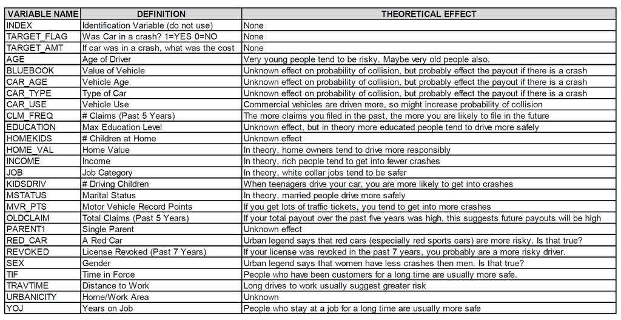

### **1. Data Exploration**

Describe the size and the variables in the insurance training data set. Consider that too much detail will cause a manager to lose interest while too little detail will make the manager consider that you aren’t doing your job. Some suggestions are given below. Please do NOT treat this as a check list of things to do to complete the assignment. You should have your own thoughts on what to tell the boss. These are just ideas.  
a. Mean / Standard Deviation / Median  
b. Bar Chart or Box Plot of the data  
c. Is the data correlated to the target variable (or to other variables?)  
d. Are any of the variables missing and need to be imputed “fixed”?

**Required Libraries**

```r
library(tidyverse)
library(Amelia)
library(naniar)
library(visdat)
library(cowplot)
library(corrplot)
library(kableExtra)
library(Hmisc)
```

**Load the data from github**

```r
url_train <- "https://raw.githubusercontent.com/chinedu2301/data621-business-analytics-data-mining/main/assignments/assignment4/insurance_training_data.csv"
url_eval <- "https://raw.githubusercontent.com/chinedu2301/data621-business-analytics-data-mining/main/assignments/assignment4/insurance-evaluation-data.csv"

training <- read_csv(url_train)
evaluation <- read_csv(url_eval)
```

**Check the head of training dataset**

```r
head(training, 10)
```

| INDEX | TARGET_FLAG | TARGET_AMT | KIDSDRIV | AGE | HOMEKIDS | YOJ | INCOME | PARENT1 | HOME_VAL | MSTATUS | SEX | EDUCATION | JOB | TRAVTIME | CAR_USE | BLUEBOOK | TIF | CAR_TYPE | RED_CAR | OLDCLAIM | CLM_FREQ | REVOKED | MVR_PTS | CAR_AGE | URBANICITY |
| --- | --- | --- | --- | --- | --- | --- | --- | --- | --- | --- | --- | --- | --- | --- | --- | --- | --- | --- | --- | --- | --- | --- | --- | --- | --- |
| 1 | 0 | 0 | 0 | 60 | 0 | 11 | $67,349 | No | $0 | z_No | M | PhD | Professional | 14 | Private | $14,230 | 11 | Minivan | yes | $4,461 | 2 | No | 3 | 18 | Highly Urban/ Urban |
| 2 | 0 | 0 | 0 | 43 | 0 | 11 | $91,449 | No | $257,252 | z_No | M | z_High School | z_Blue Collar | 22 | Commercial | $14,940 | 1 | Minivan | yes | $0 | 0 | No | 0 | 1 | Highly Urban/ Urban |
| 4 | 0 | 0 | 0 | 35 | 1 | 10 | $16,039 | No | $124,191 | Yes | z_F | z_High School | Clerical | 5 | Private | $4,010 | 4 | z_SUV | no | $38,690 | 2 | No | 3 | 10 | Highly Urban/ Urban |
| 5 | 0 | 0 | 0 | 51 | 0 | 14 | NA | No | $306,251 | Yes | M | <High School | z_Blue Collar | 32 | Private | $15,440 | 7 | Minivan | yes | $0 | 0 | No | 0 | 6 | Highly Urban/ Urban |
| 6 | 0 | 0 | 0 | 50 | 0 | NA | $114,986 | No | $243,925 | Yes | z_F | PhD | Doctor | 36 | Private | $18,000 | 1 | z_SUV | no | $19,217 | 2 | Yes | 3 | 17 | Highly Urban/ Urban |
| 7 | 1 | 2946 | 0 | 34 | 1 | 12 | $125,301 | Yes | $0 | z_No | z_F | Bachelors | z_Blue Collar | 46 | Commercial | $17,430 | 1 | Sports Car | no | $0 | 0 | No | 0 | 7 | Highly Urban/ Urban |
| 8 | 0 | 0 | 0 | 54 | 0 | NA | $18,755 | No | NA | Yes | z_F | <High School | z_Blue Collar | 33 | Private | $8,780 | 1 | z_SUV | no | $0 | 0 | No | 0 | 1 | Highly Urban/ Urban |
| 11 | 1 | 4021 | 1 | 37 | 2 | NA | $107,961 | No | $333,680 | Yes | M | Bachelors | z_Blue Collar | 44 | Commercial | $16,970 | 1 | Van | yes | $2,374 | 1 | Yes | 10 | 7 | Highly Urban/ Urban |
| 12 | 1 | 2501 | 0 | 34 | 0 | 10 | $62,978 | No | $0 | z_No | z_F | Bachelors | Clerical | 34 | Private | $11,200 | 1 | z_SUV | no | $0 | 0 | No | 0 | 1 | Highly Urban/ Urban |
| 13 | 0 | 0 | 0 | 50 | 0 | 7 | $106,952 | No | $0 | z_No | M | Bachelors | Professional | 48 | Commercial | $18,510 | 7 | Van | no | $0 | 0 | No | 1 | 17 | z_Highly Rural/ Rural |

**Get the dimension of the training dataset**

```r
dim(training)
```

```
## [1] 8161   26
```

**Get a glimpse of the training dataset**

```r
glimpse(training)
```

```
## Rows: 8,161
## Columns: 26
## $ INDEX       <dbl> 1, 2, 4, 5, 6, 7, 8, 11, 12, 13, 14, 15, 16, 17, 19, 20, 2~
## $ TARGET_FLAG <dbl> 0, 0, 0, 0, 0, 1, 0, 1, 1, 0, 1, 0, 0, 1, 1, 0, 0, 0, 0, 1~
## $ TARGET_AMT  <dbl> 0.000, 0.000, 0.000, 0.000, 0.000, 2946.000, 0.000, 4021.0~
## $ KIDSDRIV    <dbl> 0, 0, 0, 0, 0, 0, 0, 1, 0, 0, 0, 0, 0, 0, 0, 0, 0, 0, 0, 0~
## $ AGE         <dbl> 60, 43, 35, 51, 50, 34, 54, 37, 34, 50, 53, 43, 55, 53, 45~
## $ HOMEKIDS    <dbl> 0, 0, 1, 0, 0, 1, 0, 2, 0, 0, 0, 0, 0, 0, 0, 3, 0, 3, 2, 1~
## $ YOJ         <dbl> 11, 11, 10, 14, NA, 12, NA, NA, 10, 7, 14, 5, 11, 11, 0, 1~
## $ INCOME      <chr> "$67,349", "$91,449", "$16,039", NA, "$114,986", "$125,301~
## $ PARENT1     <chr> "No", "No", "No", "No", "No", "Yes", "No", "No", "No", "No~
## $ HOME_VAL    <chr> "$0", "$257,252", "$124,191", "$306,251", "$243,925", "$0"~
## $ MSTATUS     <chr> "z_No", "z_No", "Yes", "Yes", "Yes", "z_No", "Yes", "Yes",~
## $ SEX         <chr> "M", "M", "z_F", "M", "z_F", "z_F", "z_F", "M", "z_F", "M"~
## $ EDUCATION   <chr> "PhD", "z_High School", "z_High School", "<High School", "~
## $ JOB         <chr> "Professional", "z_Blue Collar", "Clerical", "z_Blue Colla~
## $ TRAVTIME    <dbl> 14, 22, 5, 32, 36, 46, 33, 44, 34, 48, 15, 36, 25, 64, 48,~
## $ CAR_USE     <chr> "Private", "Commercial", "Private", "Private", "Private", ~
## $ BLUEBOOK    <chr> "$14,230", "$14,940", "$4,010", "$15,440", "$18,000", "$17~
## $ TIF         <dbl> 11, 1, 4, 7, 1, 1, 1, 1, 1, 7, 1, 7, 7, 6, 1, 6, 6, 7, 4, ~
## $ CAR_TYPE    <chr> "Minivan", "Minivan", "z_SUV", "Minivan", "z_SUV", "Sports~
## $ RED_CAR     <chr> "yes", "yes", "no", "yes", "no", "no", "no", "yes", "no", ~
## $ OLDCLAIM    <chr> "$4,461", "$0", "$38,690", "$0", "$19,217", "$0", "$0", "$~
## $ CLM_FREQ    <dbl> 2, 0, 2, 0, 2, 0, 0, 1, 0, 0, 0, 0, 2, 0, 0, 0, 0, 0, 0, 2~
## $ REVOKED     <chr> "No", "No", "No", "No", "Yes", "No", "No", "Yes", "No", "N~
## $ MVR_PTS     <dbl> 3, 0, 3, 0, 3, 0, 0, 10, 0, 1, 0, 0, 3, 3, 3, 0, 0, 0, 0, ~
## $ CAR_AGE     <dbl> 18, 1, 10, 6, 17, 7, 1, 7, 1, 17, 11, 1, 9, 10, 5, 13, 16,~
## $ URBANICITY  <chr> "Highly Urban/ Urban", "Highly Urban/ Urban", "Highly Urba~
```

**Summary Statistics** - Mean and median of numerical columns are shown below:

```r
summary(training) %>% kbl() %>% kable_styling()
```

|  | INDEX | TARGET_FLAG | TARGET_AMT | KIDSDRIV | AGE | HOMEKIDS | YOJ | INCOME | PARENT1 | HOME_VAL | MSTATUS | SEX | EDUCATION | JOB | TRAVTIME | CAR_USE | BLUEBOOK | TIF | CAR_TYPE | RED_CAR | OLDCLAIM | CLM_FREQ | REVOKED | MVR_PTS | CAR_AGE | URBANICITY |
| --- | --- | --- | --- | --- | --- | --- | --- | --- | --- | --- | --- | --- | --- | --- | --- | --- | --- | --- | --- | --- | --- | --- | --- | --- | --- | --- |
|  | Min. : 1 | Min. :0.0000 | Min. : 0 | Min. :0.0000 | Min. :16.00 | Min. :0.0000 | Min. : 0.0 | Length:8161 | Length:8161 | Length:8161 | Length:8161 | Length:8161 | Length:8161 | Length:8161 | Min. : 5.00 | Length:8161 | Length:8161 | Min. : 1.000 | Length:8161 | Length:8161 | Length:8161 | Min. :0.0000 | Length:8161 | Min. : 0.000 | Min. :-3.000 | Length:8161 |
|  | 1st Qu.: 2559 | 1st Qu.:0.0000 | 1st Qu.: 0 | 1st Qu.:0.0000 | 1st Qu.:39.00 | 1st Qu.:0.0000 | 1st Qu.: 9.0 | Class :character | Class :character | Class :character | Class :character | Class :character | Class :character | Class :character | 1st Qu.: 22.00 | Class :character | Class :character | 1st Qu.: 1.000 | Class :character | Class :character | Class :character | 1st Qu.:0.0000 | Class :character | 1st Qu.: 0.000 | 1st Qu.: 1.000 | Class :character |
|  | Median : 5133 | Median :0.0000 | Median : 0 | Median :0.0000 | Median :45.00 | Median :0.0000 | Median :11.0 | Mode :character | Mode :character | Mode :character | Mode :character | Mode :character | Mode :character | Mode :character | Median : 33.00 | Mode :character | Mode :character | Median : 4.000 | Mode :character | Mode :character | Mode :character | Median :0.0000 | Mode :character | Median : 1.000 | Median : 8.000 | Mode :character |
|  | Mean : 5152 | Mean :0.2638 | Mean : 1504 | Mean :0.1711 | Mean :44.79 | Mean :0.7212 | Mean :10.5 | NA | NA | NA | NA | NA | NA | NA | Mean : 33.49 | NA | NA | Mean : 5.351 | NA | NA | NA | Mean :0.7986 | NA | Mean : 1.696 | Mean : 8.328 | NA |
|  | 3rd Qu.: 7745 | 3rd Qu.:1.0000 | 3rd Qu.: 1036 | 3rd Qu.:0.0000 | 3rd Qu.:51.00 | 3rd Qu.:1.0000 | 3rd Qu.:13.0 | NA | NA | NA | NA | NA | NA | NA | 3rd Qu.: 44.00 | NA | NA | 3rd Qu.: 7.000 | NA | NA | NA | 3rd Qu.:2.0000 | NA | 3rd Qu.: 3.000 | 3rd Qu.:12.000 | NA |
|  | Max. :10302 | Max. :1.0000 | Max. :107586 | Max. :4.0000 | Max. :81.00 | Max. :5.0000 | Max. :23.0 | NA | NA | NA | NA | NA | NA | NA | Max. :142.00 | NA | NA | Max. :25.000 | NA | NA | NA | Max. :5.0000 | NA | Max. :13.000 | Max. :28.000 | NA |
|  | NA | NA | NA | NA | NA’s :6 | NA | NA’s :454 | NA | NA | NA | NA | NA | NA | NA | NA | NA | NA | NA | NA | NA | NA | NA | NA | NA | NA’s :510 | NA |

#### **Understand the data using visuals**

**Target Flag - Was Car in a crash? 1=YES, 0=NO**

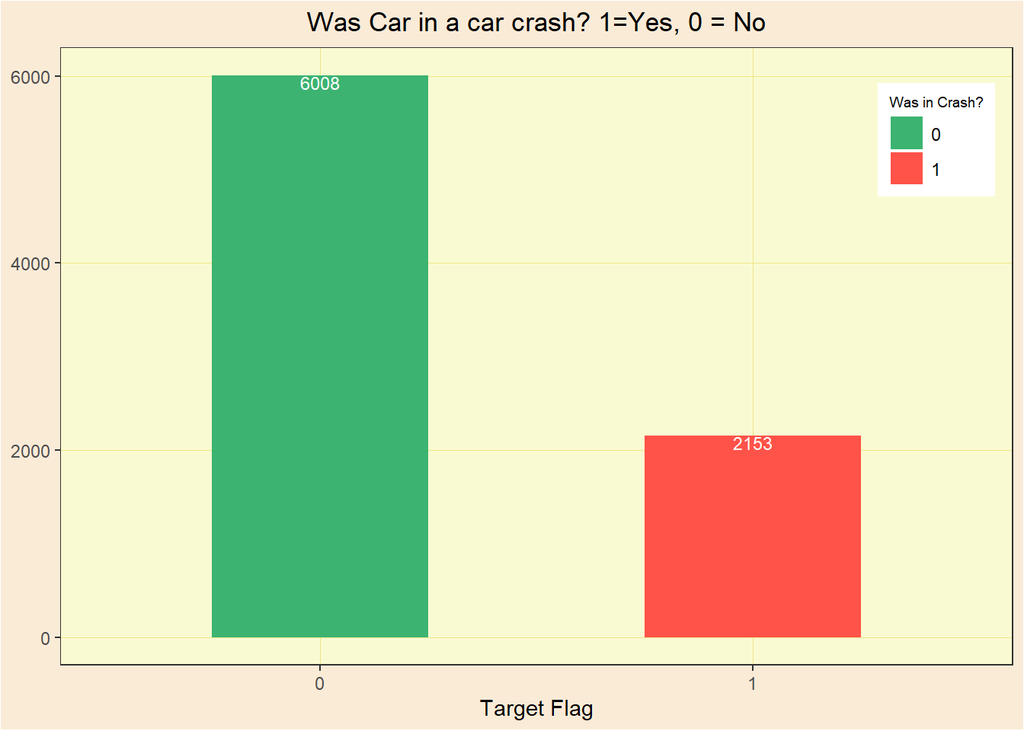

```r
# plot a bar chart to show the distribution of car crash
target_flag <- training %>% ggplot(aes(x = as.factor(TARGET_FLAG), fill = as.factor(TARGET_FLAG))) +
    geom_bar(width = 0.5) + theme_bw() +
    geom_text(stat = 'count', aes(label = ..count..), vjust = 1, color = "white", size = 3.2) +
    scale_fill_manual("Was in Crash?", values = c("0" = "#3CB371", "1" = "#FF5349")) +
    theme(panel.grid.major = element_line(colour = "khaki2",
    linetype = "blank"), plot.title = element_text(face = "bold",
    hjust = 0.5), panel.background = element_rect(fill = "lightgoldenrodyellow"),
    plot.background = element_rect(fill = "antiquewhite")) +labs(title = "Was Car in a car crash? 1=Yes, 0 = No",
    x = "Target Flag", y = NULL) + theme(panel.grid.minor = element_line(linetype = "blank"),
    plot.title = element_text(face = "plain"),
    legend.title = element_text(size = 7),
    legend.position = c(0.92, 0.85)) + theme(panel.grid.major = element_line(size = 0.2,
    linetype = "solid"))

# display the chart
target_flag
```

**Car crash by Gender**

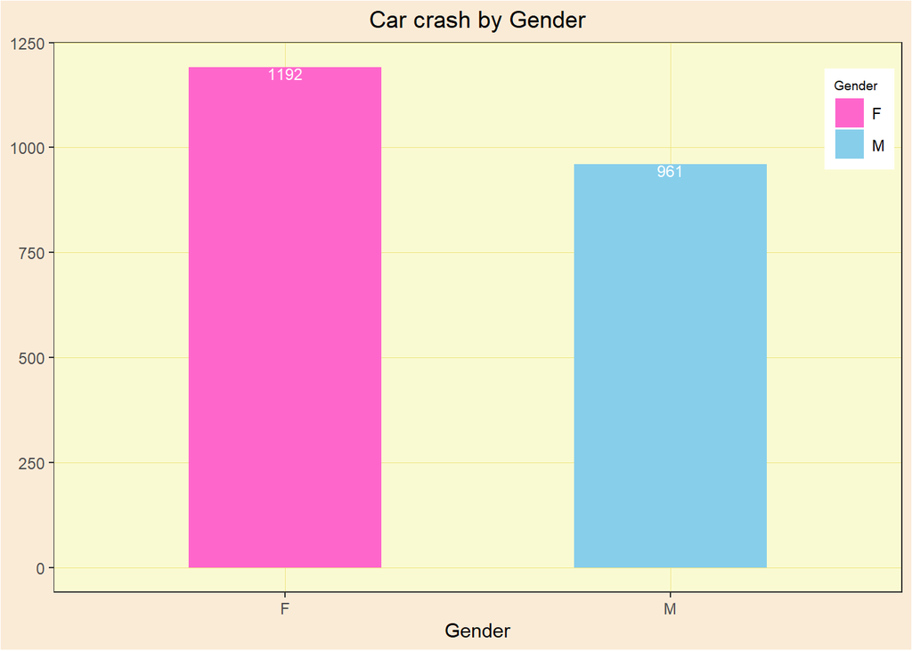

```r
# clean the SEX column
training$SEX <- gsub("z_", "", training$SEX)

# plot the gender distribution
car_crash_gender <- training %>% filter(TARGET_FLAG == 1) %>% ggplot(aes(x = as.factor(SEX),
                                                                         fill = as.factor(SEX))) +
    geom_bar(width = 0.5) + theme_bw() +
    geom_text(stat = 'count', aes(label = ..count..), vjust = 1, color = "white", size = 3.2) +
    scale_fill_manual("Gender", values = c("F" = "#FF66CC", "M" = "#87CEEB")) +
    theme(panel.grid.major = element_line(colour = "khaki2",
    linetype = "blank"), plot.title = element_text(face = "bold",
    hjust = 0.5), panel.background = element_rect(fill = "lightgoldenrodyellow"),
    plot.background = element_rect(fill = "antiquewhite")) +labs(title = "Car crash by Gender",
    x = "Gender", y = NULL) + theme(panel.grid.minor = element_line(linetype = "blank"),
    plot.title = element_text(face = "plain"),
    legend.title = element_text(size = 7),
    legend.position = c(0.95, 0.86)) + theme(panel.grid.major = element_line(size = 0.2,
    linetype = "solid"))
car_crash_gender
```

**Age Distribution**

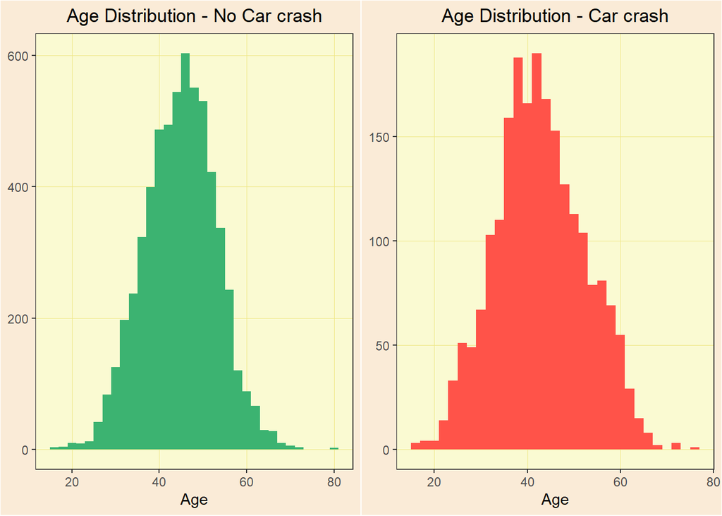

```r
# plot the age distribution of individuals involved in a crash
age_crash <- training %>% filter(TARGET_FLAG == 1) %>% ggplot(aes(x = AGE)) +
    geom_histogram(binwidth = 2, fill = "#FF5349") + theme_bw() +
    theme(panel.grid.major = element_line(colour = "khaki2",
    linetype = "blank"), plot.title = element_text(face = "bold",
    hjust = 0.5), panel.background = element_rect(fill = "lightgoldenrodyellow"),
    plot.background = element_rect(fill = "antiquewhite")) +
    labs(title = "Age Distribution - Car crash",
    x = "Age", y = NULL) + theme(panel.grid.minor = element_line(linetype = "blank"),
    plot.title = element_text(face = "plain"),
    legend.title = element_text(size = 7),
    legend.position = c(0.95, 0.86)) + theme(panel.grid.major = element_line(size = 0.2,
    linetype = "solid"))

# plot the age distribution of individuals not involved in a crash
age_no_crash <- training %>% filter(TARGET_FLAG == 0) %>% ggplot(aes(x = AGE)) +
    geom_histogram(binwidth = 2, fill = "#3CB371") + theme_bw() +
    theme(panel.grid.major = element_line(colour = "khaki2",
    linetype = "blank"), plot.title = element_text(face = "bold",
    hjust = 0.5), panel.background = element_rect(fill = "lightgoldenrodyellow"),
    plot.background = element_rect(fill = "antiquewhite")) +
    labs(title = "Age Distribution - No Car crash",
    x = "Age", y = NULL) + theme(panel.grid.minor = element_line(linetype = "blank"),
    plot.title = element_text(face = "plain"),
    legend.title = element_text(size = 7),
    legend.position = c(0.95, 0.86)) + theme(panel.grid.major = element_line(size = 0.2,
    linetype = "solid"))

# display the plots
plot_grid(age_no_crash, age_crash)
```

**Car crash by Car Type**

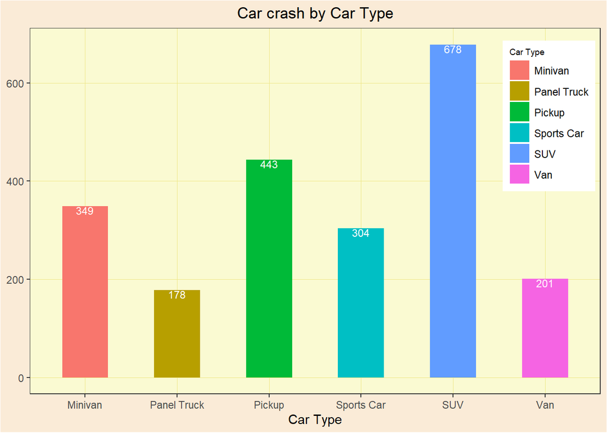

```r
# clean the CAR_TYPE column
training$CAR_TYPE <- gsub("z_", "", training$CAR_TYPE)

# plot the gender distribution
car_crash_car_type <- training %>% filter(TARGET_FLAG == 1) %>% ggplot(aes(x = as.factor(CAR_TYPE),
                                                                         fill = as.factor(CAR_TYPE))) +
    geom_bar(width = 0.5) + theme_bw() + scale_fill_discrete(name = "Car Type") +
    geom_text(stat = 'count', aes(label = ..count..), vjust = 1, color = "white", size = 3.2) +
    theme(panel.grid.major = element_line(colour = "khaki2",
    linetype = "blank"), plot.title = element_text(face = "bold",
    hjust = 0.5), panel.background = element_rect(fill = "lightgoldenrodyellow"),
    plot.background = element_rect(fill = "antiquewhite")) +labs(title = "Car crash by Car Type",
    x = "Car Type", y = NULL) + theme(panel.grid.minor = element_line(linetype = "blank"),
    plot.title = element_text(face = "plain"),
    legend.title = element_text(size = 7),
    legend.position = c(0.91, 0.76)) + theme(panel.grid.major = element_line(size = 0.2,
    linetype = "solid"))
car_crash_car_type
```

**Missing Values**  
*Visualize the missing data using the Amelia package*

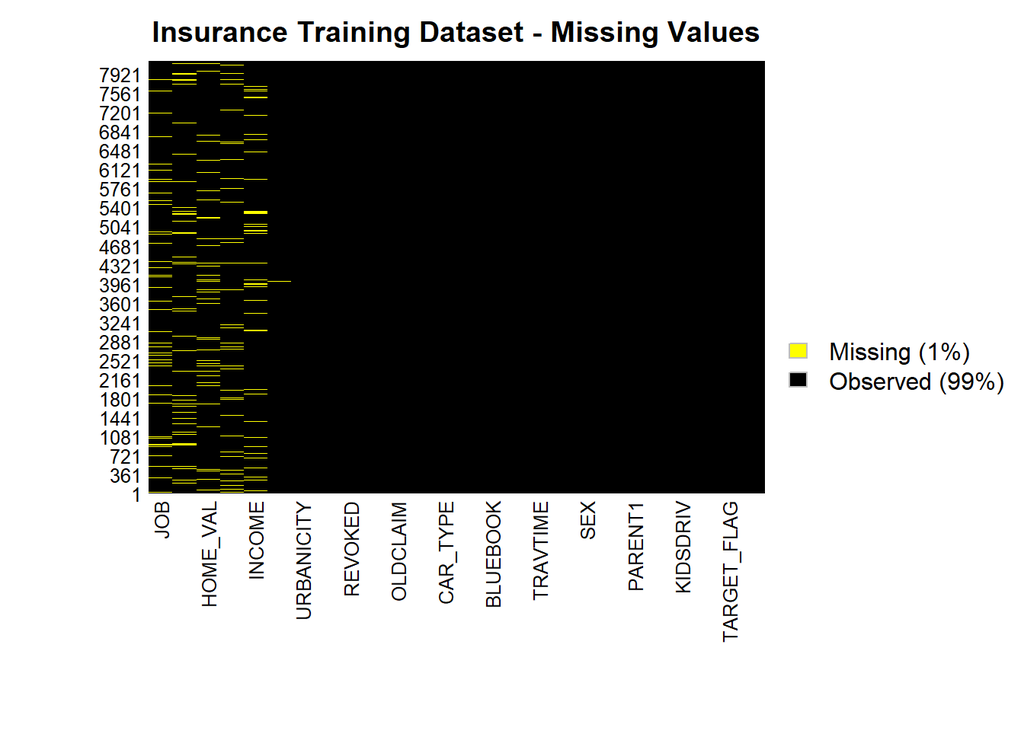

```r
# check for NA values using the missmap function from Amelia package
missmap(training, main = "Insurance Training Dataset - Missing Values",
        col = c("yellow", "black"), margins = c(8,5))
```

*Visualize the percentage of missingness in each column using the nanair package*

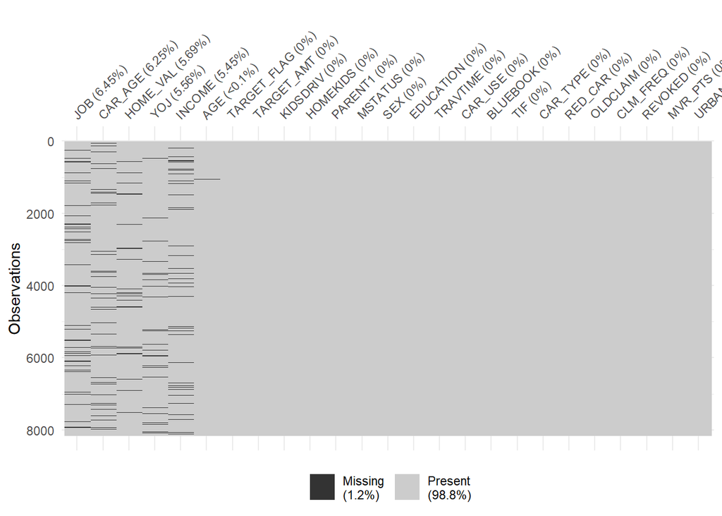

```r
# visualize missing values and the percentage of missingness for each column
training %>% select(-INDEX) %>% vis_miss(sort_miss = TRUE)
```

*Visualize the missing values using visdat package*

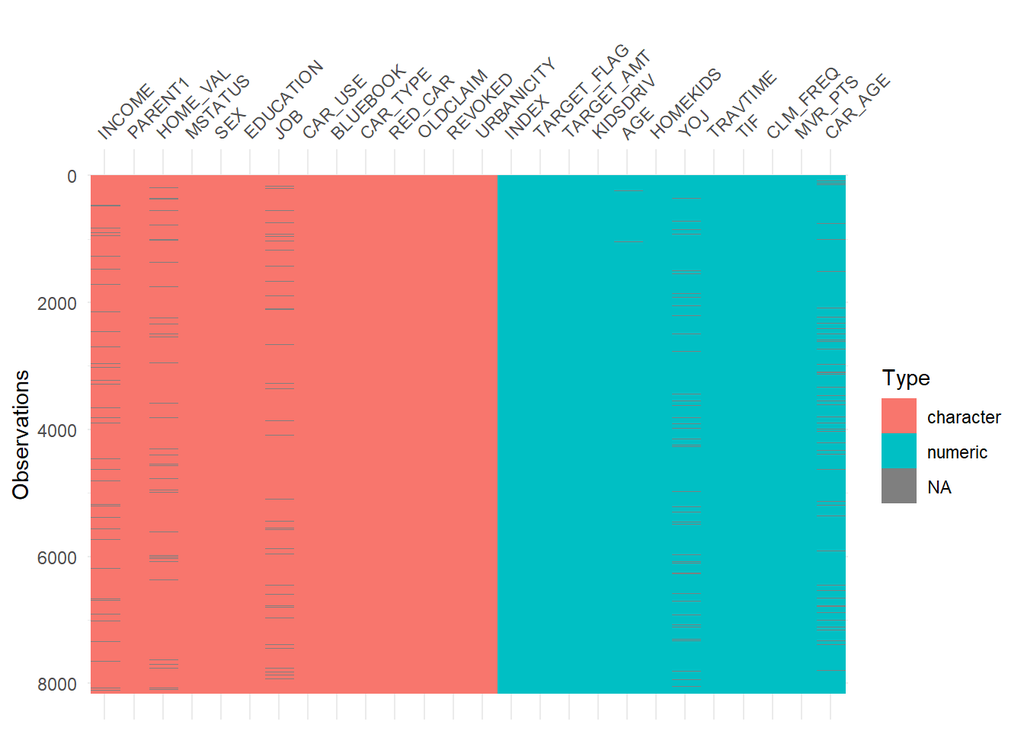

```r
# visualize the missing values and their data type using vis_dat
vis_dat(training)
```

**Clean the dataset**

```r
# Create a function to remove "$", "," and convert to numeric
clean_money = function(in_col) {
  # this function accepts a currency column and removes any occurrence of "$" and "," and converts it to numeric
  remove_dollar_sign = gsub("\\$", "", in_col)
  remove_comma = gsub(",", "", remove_dollar_sign)
  out_col <- as.numeric(remove_comma)
  return(out_col)
}

# Create a function to remove "z_" and "<"
remove_z = function(in_col){
  # this function accepts a column and removes any occurrence of the strings "z_" or "<" from the column
  rem_z <- gsub("z_", "", in_col)
  out_col <- gsub("<", "", rem_z)
  return (out_col)
}

# apply the cleaning functions to the applicable columns in the training dataset
training <- training %>% mutate_at(c("INCOME","HOME_VAL","BLUEBOOK","OLDCLAIM"), clean_money) %>%
  mutate_at(c("EDUCATION","JOB","CAR_TYPE","URBANICITY", "MSTATUS"), remove_z)

head(training, 10)
```

| INDEX | TARGET_FLAG | TARGET_AMT | KIDSDRIV | AGE | HOMEKIDS | YOJ | INCOME | PARENT1 | HOME_VAL | MSTATUS | SEX | EDUCATION | JOB | TRAVTIME | CAR_USE | BLUEBOOK | TIF | CAR_TYPE | RED_CAR | OLDCLAIM | CLM_FREQ | REVOKED | MVR_PTS | CAR_AGE | URBANICITY |
| --- | --- | --- | --- | --- | --- | --- | --- | --- | --- | --- | --- | --- | --- | --- | --- | --- | --- | --- | --- | --- | --- | --- | --- | --- | --- |
| 1 | 0 | 0 | 0 | 60 | 0 | 11 | 67349 | No | 0 | No | M | PhD | Professional | 14 | Private | 14230 | 11 | Minivan | yes | 4461 | 2 | No | 3 | 18 | Highly Urban/ Urban |
| 2 | 0 | 0 | 0 | 43 | 0 | 11 | 91449 | No | 257252 | No | M | High School | Blue Collar | 22 | Commercial | 14940 | 1 | Minivan | yes | 0 | 0 | No | 0 | 1 | Highly Urban/ Urban |
| 4 | 0 | 0 | 0 | 35 | 1 | 10 | 16039 | No | 124191 | Yes | F | High School | Clerical | 5 | Private | 4010 | 4 | SUV | no | 38690 | 2 | No | 3 | 10 | Highly Urban/ Urban |
| 5 | 0 | 0 | 0 | 51 | 0 | 14 | NA | No | 306251 | Yes | M | High School | Blue Collar | 32 | Private | 15440 | 7 | Minivan | yes | 0 | 0 | No | 0 | 6 | Highly Urban/ Urban |
| 6 | 0 | 0 | 0 | 50 | 0 | NA | 114986 | No | 243925 | Yes | F | PhD | Doctor | 36 | Private | 18000 | 1 | SUV | no | 19217 | 2 | Yes | 3 | 17 | Highly Urban/ Urban |
| 7 | 1 | 2946 | 0 | 34 | 1 | 12 | 125301 | Yes | 0 | No | F | Bachelors | Blue Collar | 46 | Commercial | 17430 | 1 | Sports Car | no | 0 | 0 | No | 0 | 7 | Highly Urban/ Urban |
| 8 | 0 | 0 | 0 | 54 | 0 | NA | 18755 | No | NA | Yes | F | High School | Blue Collar | 33 | Private | 8780 | 1 | SUV | no | 0 | 0 | No | 0 | 1 | Highly Urban/ Urban |
| 11 | 1 | 4021 | 1 | 37 | 2 | NA | 107961 | No | 333680 | Yes | M | Bachelors | Blue Collar | 44 | Commercial | 16970 | 1 | Van | yes | 2374 | 1 | Yes | 10 | 7 | Highly Urban/ Urban |
| 12 | 1 | 2501 | 0 | 34 | 0 | 10 | 62978 | No | 0 | No | F | Bachelors | Clerical | 34 | Private | 11200 | 1 | SUV | no | 0 | 0 | No | 0 | 1 | Highly Urban/ Urban |
| 13 | 0 | 0 | 0 | 50 | 0 | 7 | 106952 | No | 0 | No | M | Bachelors | Professional | 48 | Commercial | 18510 | 7 | Van | no | 0 | 0 | No | 1 | 17 | Highly Rural/ Rural |

**Correlation**

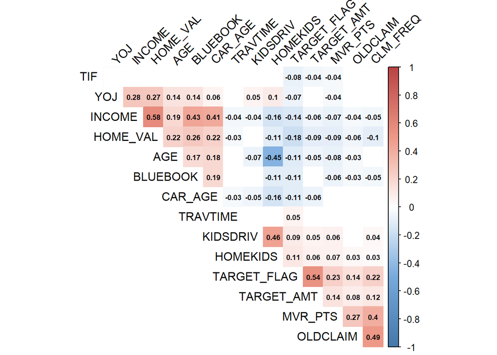

```r
# select only numeric columns excluding the INDEX column
corr_data <- select_if(training, is.numeric) %>%  select(-INDEX)
# get the correlation
training_corr = corr_data %>% cor(corr_data, use = "na.or.complete" )
# define the color pallete to use in the correlation plot
col <- colorRampPalette(c("#4477AA", "#77AADD", "#FFFFFF", "#EE9988", "#BB4444"))
# get the matrix of p_values using the rcorr function from the Hmisc package
p_mat <- rcorr(as.matrix(corr_data))$P
# correlation plot
corrplot(training_corr, method="color", col=col(200),
         type="upper", order="hclust",
         addCoef.col = "black", # Add coefficient of correlation
         number.cex = 0.6,
         tl.col="black", tl.srt=45, #Text label color and rotation
         # Combine with significance
         p.mat = p_mat, sig.level = 0.01, insig = "blank",
         # hide correlation coefficient on the principal diagonal
         diag=FALSE
         )
```